# NLP Text Predict - Exploratory Data Analysis

Jiali Lei

7/7/2020

### Introduction

A smart keyboard can make typing on mobile devices easier in our daily lives, and there are companies developing such technology using natural language processing and predictive text models. SwiftKey, the capstone project partner, is one of the leading companies in the field and provided data for data scientists to build a predictive text product. In this exploratory data analysis, we will perform some basic analyses to understand the text data sets and lay out a preliminary plan for the steps in prediction model selections.

### Data

This is the training data to get started, [Dataset](https://d396qusza40orc.cloudfront.net/dsscapstone/dataset/Coursera-SwiftKey.zip). It consists 4 locales, en_US, de_DE, ru_RU, and fi_FI. For this project, we will explore the text files in english (en_US).

### Exploratory Data Analysis

#### **Load Data**

```r
## Load the necessary packages
library(ggplot2)
library(tm)
library(wordcloud)
library(RColorBrewer)
library(ngram)
```

```r
## set to the desired directory and create a data directory
if (!file.exists("data")){
        dir.create("data")
}

## Download the data
dataURL <- "https://d396qusza40orc.cloudfront.net/dsscapstone/dataset/Coursera-SwiftKey.zip"
download.file(dataURL, destfile = "./data/swiftkey.zip", method = "curl")
unzip("./data/swiftkey.zip", exdir = "./data")
## file.remove("./data/swiftkey.zip")
```

#### Basic Summary of Text Files

```r
## get the path directory of the en_US .txt files
flist <- list.files(path = "./data",
                    recursive = TRUE,
                    pattern = ".*en_.*.txt")
flist <- paste("./data", flist, sep="/")

## custom function to get the line count, word count, and the file size
finfo <- sapply(flist, function(f){
        # file size in MB
        fsize <- file.info(f)[1]/1024/1024

        # read lines of the file
        con <- file(f, open="r")
        tf <- readLines(con)
        close(con)

        # line count of file
        lc <- length(tf)

        # word count of file
        wc <- sum(nchar(tf))

        data.frame(fsize, lc, wc)
})
# convert finfo matrix to data frame
finfo <- data.frame(t(finfo))
colnames(finfo) <- c("file_size_MB", "line_count", "word_count")
```

```r
## sample 1% of text corpus
t_sub <- function(f, percent=0.01){
        con <- file(f, open="r")
        tf <- readLines(con, encoding = "UTF-8", skipNul = TRUE)
        close(con)
        # remove non-English words
        tf <- iconv(tf, "latin1", "ASCII", sub = "")
        set.seed(1011)
        sample(tf, length(tf) * percent)
}

## create a corpus from samples of the 3 en_US *.txt files
tCorpus <- VCorpus(VectorSource(sapply(flist, t_sub)))
```

#### Preprocess Corpus with **tm** transformations

Use **tm_map()** function from **tm** package to perform transformations on the Corpus created above. Examples of transformation include removing whitespace, remove storwords, stemming, etc.

```r
# eliminate extra whitespace
tCorpus <- tm_map(tCorpus, stripWhitespace)
# convert to lower case
tCorpus <- tm_map(tCorpus, content_transformer(tolower))
# remove stopwords
tCorpus <- tm_map(tCorpus, removeWords, stopwords("english"))
# stemming
tCorpus <- tm_map(tCorpus, stemDocument)
# remove numbers
tCorpus <- tm_map(tCorpus, removeNumbers)
# remove punctuations
tCorpus <- tm_map(tCorpus, removePunctuation)
```

#### Create a Document-Term Matrix

Next, we convert the corpus to a document matrix to count the word frequency, which can be visualized with a word cloud.

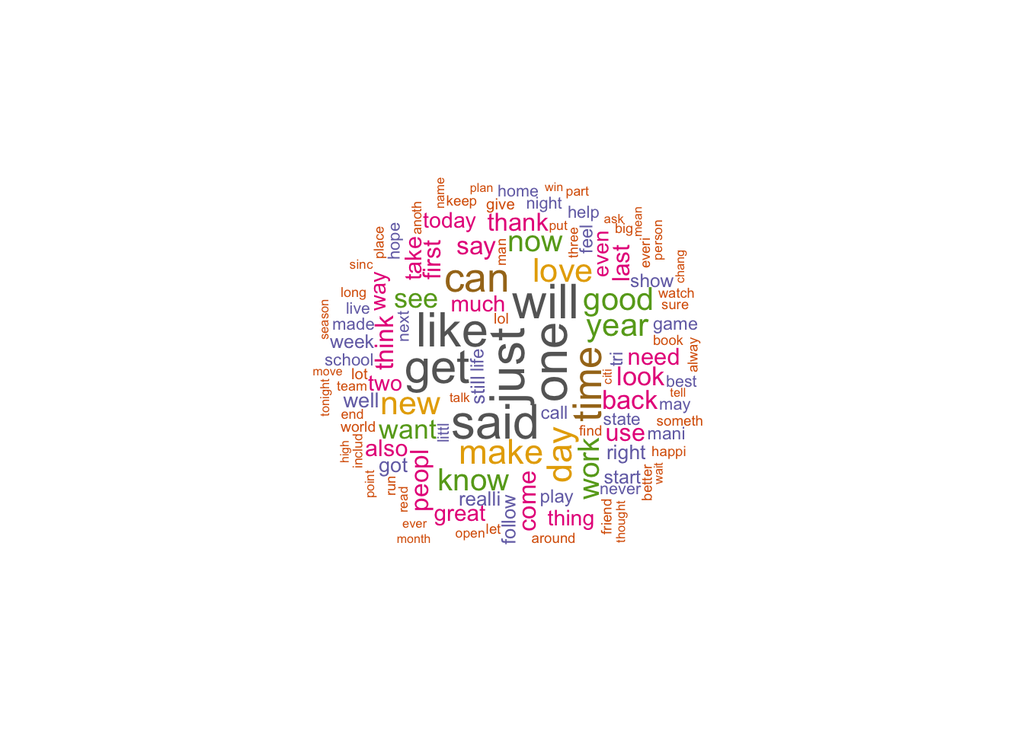

```r
# create a term-document matrix
dtm <- DocumentTermMatrix(tCorpus)
dtm_mat <- as.matrix(dtm)
# tally up the frequency of each word across 3 text files, and sort in descending order
words <- sort(colSums(dtm_mat), decreasing = TRUE)
dtm_df <- data.frame(word = names(words), freq = words)
# create a word cloud to show more frequent words
set.seed(1234)
wordcloud::wordcloud(words = dtm_df$word,
                     freq = dtm_df$freq,
                     min.freq = 500,
                     max.words = 300,
                     rot.per = 0.35,
                     random.order = FALSE,
                     scale = c(2, 0.2),
                     colors = brewer.pal(8, "Dark2"))
```

### N-Gram Modeling

An n-gram model is a type of probabilistic language model for predicting the next item in such a sequence in the form of a (n-1)-order Markov model.

**NOTE**: Uni-gram is equivalent to what the previous word cloud shows the frequency of each word in the 3 text files.

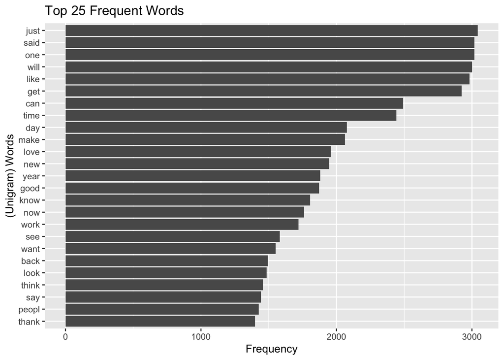

```r
# create tokenizer for 1-4 grams
unigramTokenizer <- function(x)
        unlist(lapply(ngrams(words(x), 1), paste, collapse=" "), use.names = FALSE)
bigramTokenizer <- function(x)
        unlist(lapply(ngrams(words(x), 2), paste, collapse=" "), use.names = FALSE)
trigramTokenizer <- function(x)
        unlist(lapply(ngrams(words(x), 3), paste, collapse=" "), use.names = FALSE)
quadgramTokenizer <- function(x)
        unlist(lapply(ngrams(words(x), 4), paste, collapse=" "), use.names = FALSE)

# convert corpus to document term matrix per n-grams
unigram_dtm <- DocumentTermMatrix(tCorpus, control = list(tokenize=unigramTokenizer))
bigram_dtm <- DocumentTermMatrix(tCorpus, control = list(tokenize=bigramTokenizer))
trigram_dtm <- DocumentTermMatrix(tCorpus, control = list(tokenize=trigramTokenizer))
quadgram_dtm <- DocumentTermMatrix(tCorpus, control = list(tokenize=quadgramTokenizer))

# a function to tally up the frequency of each word across 3 text files, and sort in descending order
ngram_dtm_df <- function(x) {
        x_mat <- as.matrix(x)
        n_grams <- sort(colSums(x_mat), decreasing = TRUE)
        x_df <- data.frame(n_grams = names(n_grams), freq = n_grams)
}
unigram_df <- ngram_dtm_df(unigram_dtm)
bigram_df <- ngram_dtm_df(bigram_dtm)
trigram_df <- ngram_dtm_df(trigram_dtm)
quadgram_df <- ngram_dtm_df(quadgram_dtm)

# plot the top frequent words or 2-/3-/4-grams phrases in the combined corpus
ggplot(unigram_df[1:25,], aes(x=reorder(n_grams, freq), y=freq)) +
        geom_bar(stat = "identity") +
        coord_flip() +
        xlab("(Unigram) Words") +
        ylab("Frequency") +
        labs(title = "Top 25 Frequent Words")
```

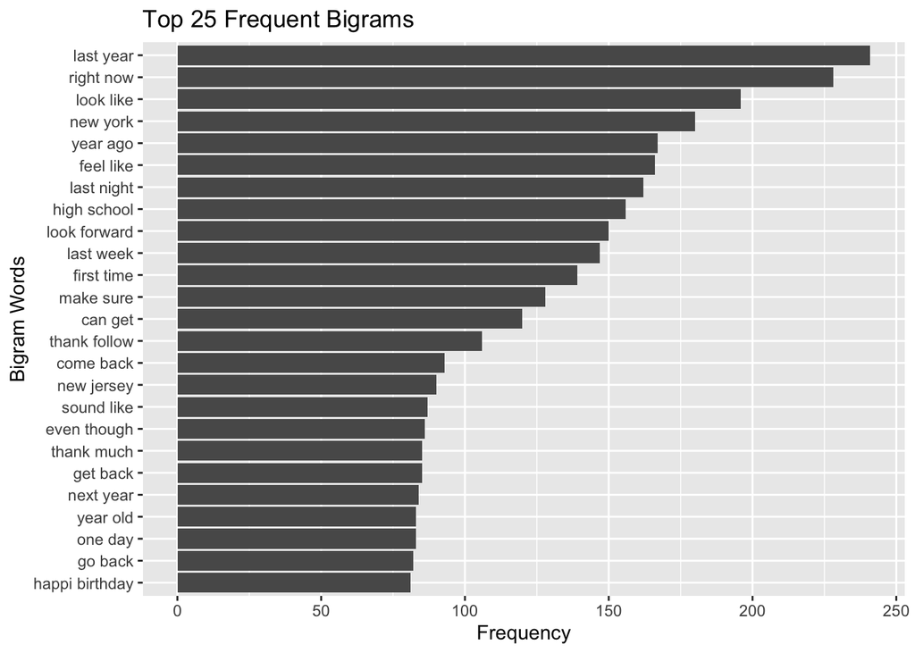

```r
ggplot(bigram_df[1:25,], aes(x=reorder(n_grams, freq), y=freq)) +
        geom_bar(stat = "identity") +
        coord_flip() +
        xlab("Bigram Words") +
        ylab("Frequency") +
        labs(title = "Top 25 Frequent Bigrams")
```

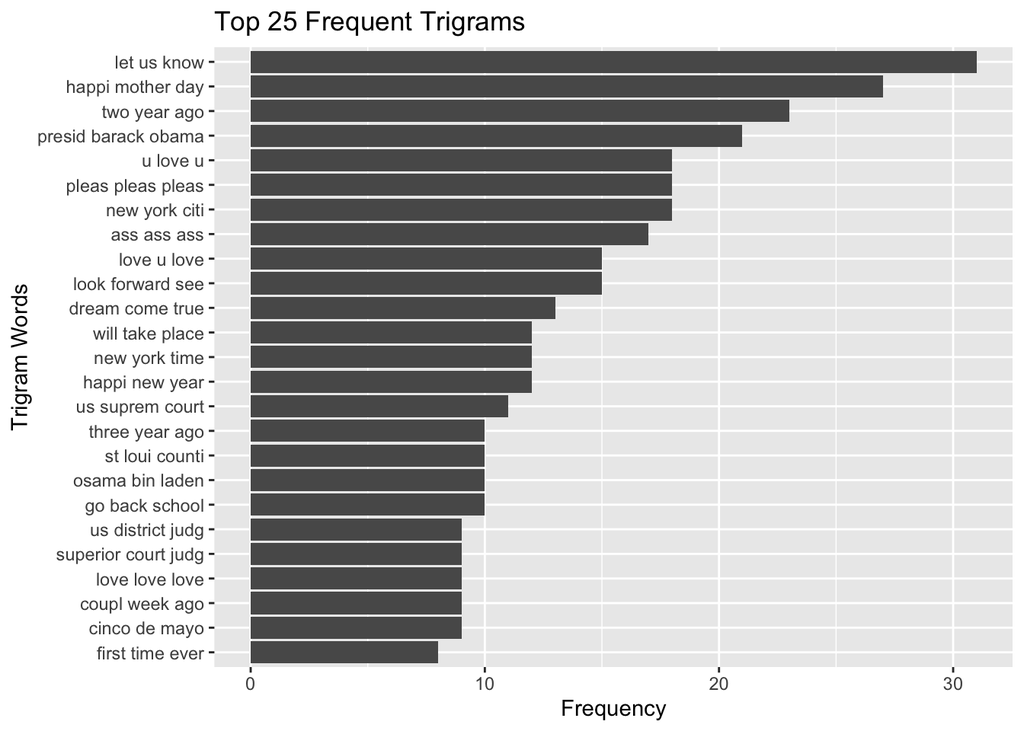

```r
ggplot(trigram_df[1:25,], aes(x=reorder(n_grams, freq), y=freq)) +
        geom_bar(stat = "identity") +
        coord_flip() +
        xlab("Trigram Words") +
        ylab("Frequency") +
        labs(title = "Top 25 Frequent Trigrams")
```

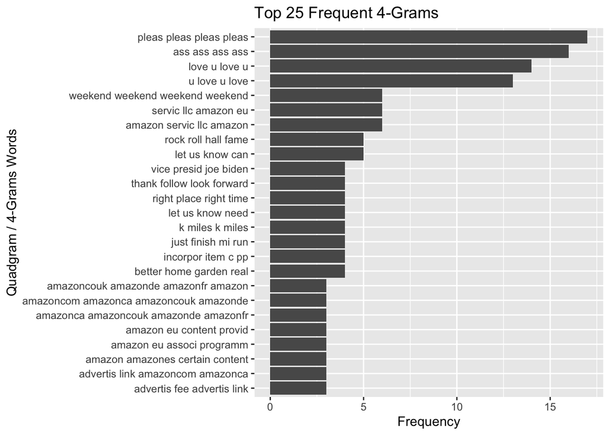

```r
ggplot(quadgram_df[1:25,], aes(x=reorder(n_grams, freq), y=freq)) +
        geom_bar(stat = "identity") +
        coord_flip() +
        xlab("Quadgram / 4-Grams Words") +
        ylab("Frequency") +
        labs(title = "Top 25 Frequent 4-Grams")
```

#### N-Gram Prediction

The prediction of the n-th word in n-grams model is based on the (n-1)-gram of the n-gram dictionary. For example if a user typed “let us” (bi-grams) on a keyboard, the prediction model will look through the tri-gram dictionary and suggest the next word based on the most frequent tri-grams starting with “let us”.

```
##                     n_grams freq
## let us know     let us know   31
## let us help     let us help    4
## let us choose let us choose    1
```

### Next Plan

- The analysis and visualization above is based on the combined corpus of blogs, news, and twitter, so it’s worth considering the frequency of words and n-grams from each file. Consider the term frequency-inverse document frequency ([tf-idf](https://en.wikipedia.org/wiki/Tf–idf)) to appropriate the weight of terms from each file in the prediction model.
- If the n-grams dictionary is not sufficient to predict the next word, then consider (1) expand the training corpus to increase the variety of texts and build a better n-grams dictionary; (2) “downgrade” from n-grams dictionary to (n-1)-grams dictionary to predict the next word; for example, 5-grams dictionary doesn’t contain a phrase starting with “wish you happy new”, then look for “you happy new” in 4-grams dictionary for the prediction of the next word, then look for “happy new” in 3-grams dictionary if 4-grams dictionary has nothing to match the phrase, and so on and so forth till the most frequent word (uni-grams); (3) directly suggest “the”, “and”, or the most frequent stopwords if all fails.
- Perform sentence sentiment analysis to predict what the user types is of positive or negative sense; consider remove profanity or other abusive words from the data.
- Consider other prediction methods such as clustering words or phrases and calculating distance/association score between words to suggest the next word.

### Reference Documents

1. [Introduction to the **tm** Package - Text Mining in R](https://cran.r-project.org/web/packages/tm/vignettes/tm.pdf)
2. [Guide to the **ngram** Package](https://cran.r-project.org/web/packages/ngram/vignettes/ngram-guide.pdf)
3. [tf-idf](https://en.wikipedia.org/wiki/Tf–idf)